# Migration and LU Change in the Tropics

Friday January 30, 2015

## Introduction

Goals:

- Change maps for land use types Forest, Agriculture & Urban Land Use
- Mean migration rates per subnational level

Data:

- Modis Land cover (extent = world, resolution 5 min -> +- 10 km)
- CIESIN migration (extent = world, resolution 1 km)

Extent:

- Whole tropics, this project: Malaysia

## Method

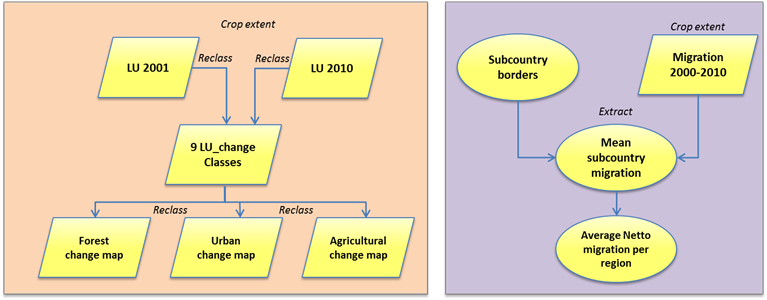

## Loading…

We will load and use the following libraries:

- **raster**
- **rgdal**
- **R.utils**
- **caret**
- **e1071**
- **ggplot2**
- **googleVis**
- **rasterVis**
- **ISOcodes**

## Then we crop to country of choice

…which is today Malaysia

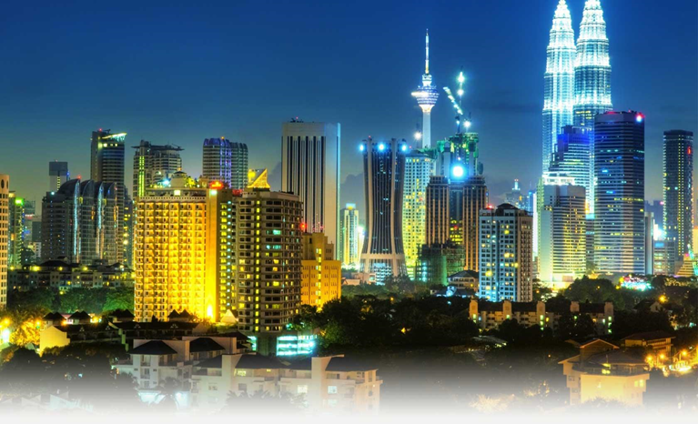

## Then we…

- Mask Landuse & Migration data to country of choice

(which is… Malaysia )

- Resample migration data (1x1 km) to coarser cell size (10x10 km)
- Simplify 16 Land Use classes to 4 {raster::reclassify}:
  - forest
  - other vegetation
  - agriculture
  - urban

## **LAND USE**

## Land use maps after reclassification

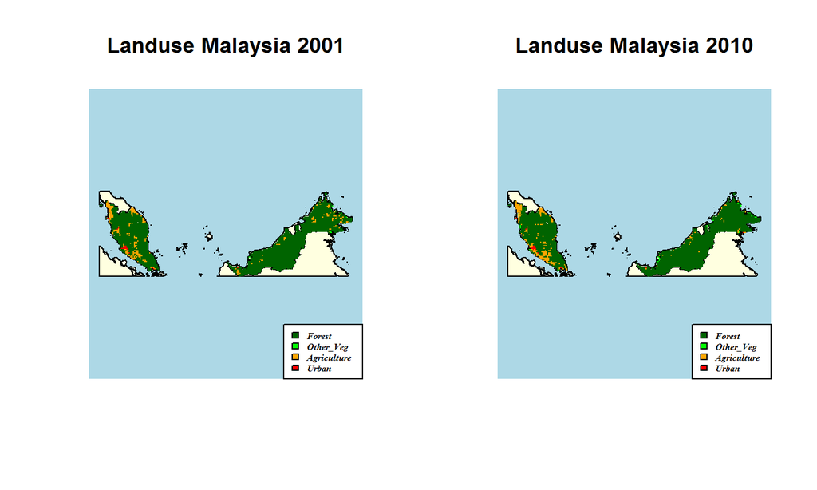

## Statistics…

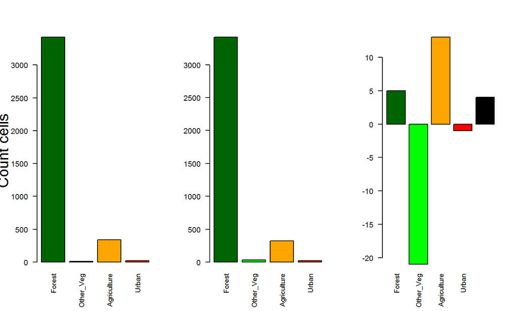

## Confusion matrix (1)

We used the following code:

```r
LUasVec_2001 <- as.vector(LU_Ras_Simple$LU_2001)
LUasVec_2010 <- as.vector(LU_Ras_Simple$LU_2010)
CF_mat <- confusionMatrix(LUasVec_2001, LUasVec_2010)
CF_mat <- CF_mat$table
row.names(CF_mat) <- (c("Forest2001", 'Other veg2001',
                        'Agriculture2001','Urban2001'))
colnames(CF_mat) <- (c('Forest2010', 'Other veg2010',
                       'Agriculture2010','Urban2010'))
```

Which will show the count of cells for every LU change type

## Confusion matrix (2)

```r
print(CF_mat)
```

```
##                  Reference
## Prediction        Forest2010 Other veg2010 Agriculture2010 Urban2010
##   Forest2001            3268            20             129         1
##   Other veg2001            1            10               0         0
##   Agriculture2001        145             0             192         1
##   Urban2001                0             0               0        19
```

This shows per conversion type the count of cells

## Land use change

- 16 unique LU change types
- LU2001*10 + LU 2010 -> unique change ID
- reclassify per LU change type -> (Loss, NoChange, Gain)

## LU Change (1)

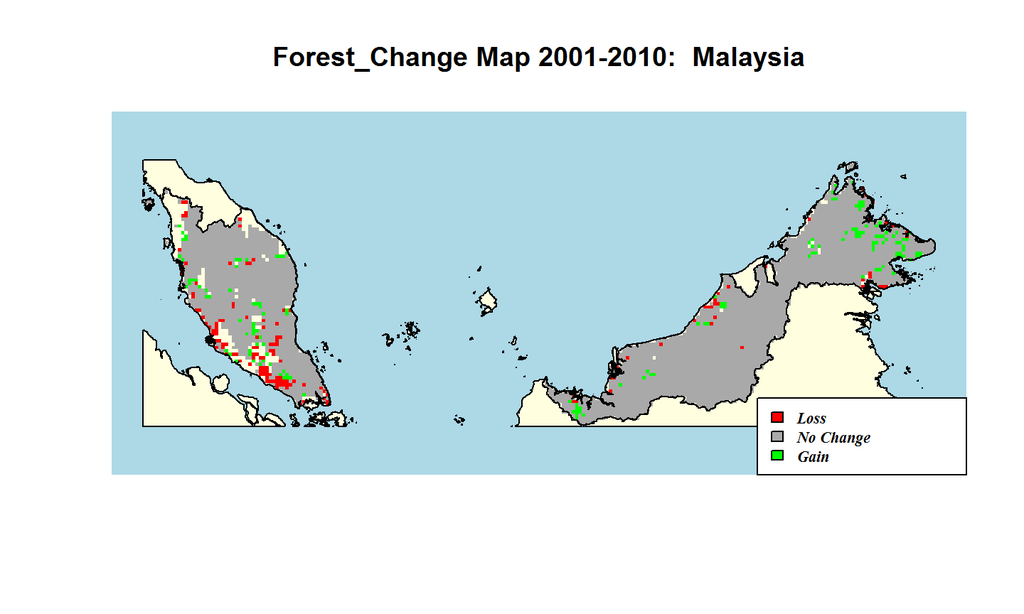

```r
PlotChange(Forest_Change)
```

## LU Change (2)

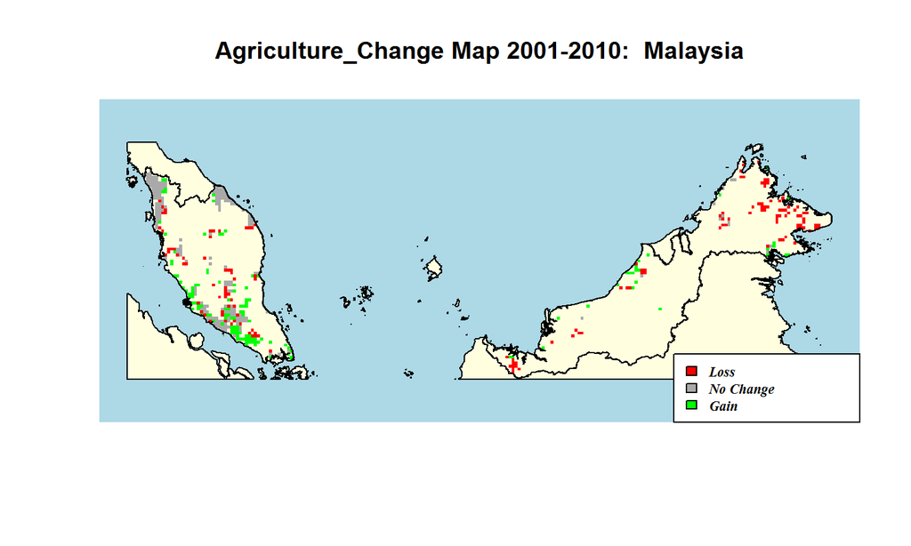

```r
PlotChange(Agriculture_Change)
```

## LU Change (3)

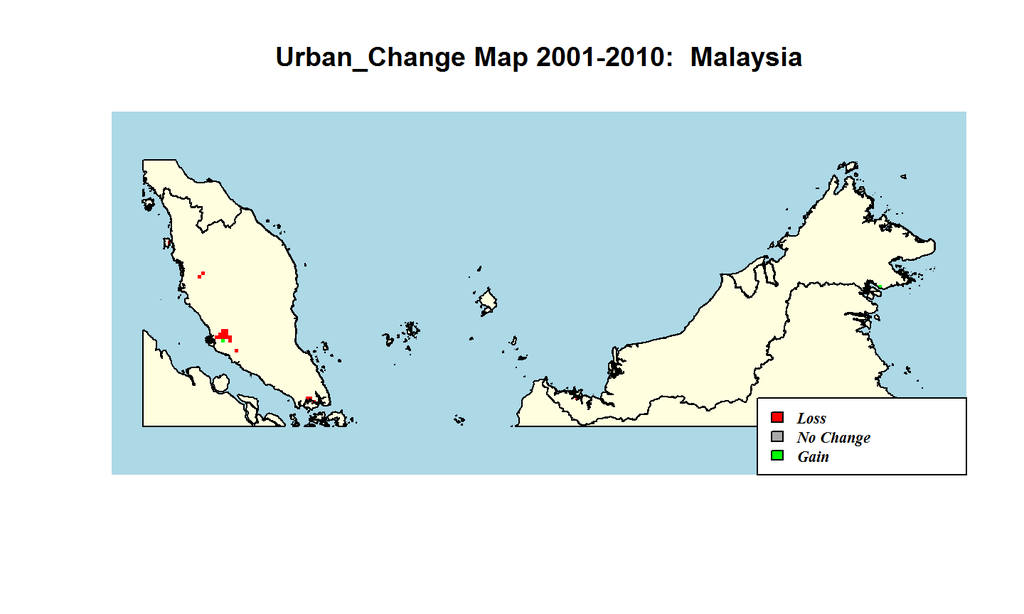

```r
PlotChange(Urban_Change)
```

## **MIGRATION**

We chose mean migration per subnatinal level because count would not be relative to size of region

## Statistics…

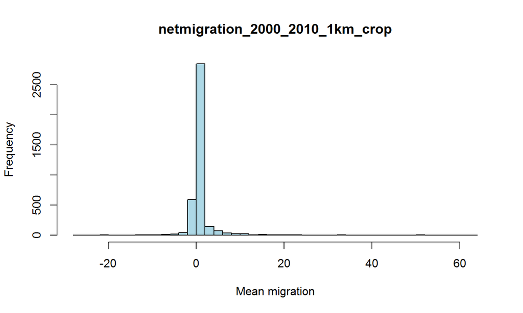

```r
hist(migr_bigcell, col=c('lightblue'), breaks = 50, xlab = 'Mean migration')
```

## We extract mean migration per subnational level…

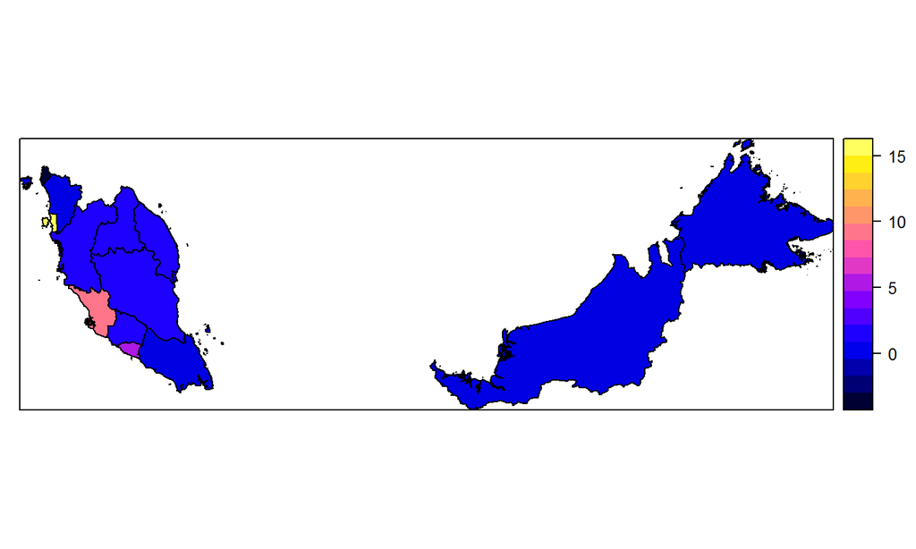

## A GoogleVis map is created

```r
HTML <- gvisGeoChart(Migr_sub_final_plot,locationvar = "Code",
                     colorvar = "Average Migration",
                     options=list(region="MY", resolution="provinces",
                     dataMode='regions'))
```

## Concluding

- Course provided useful tools for this project, we feel more confident with using R
- Thanks to R, all our *mistakes* did not cause us having RSI
- Script not completely generic, improvement would be more functions